# Representation Matters: How do we get it?

Representation Matters: How do we get it? The impact of gender quotas on women’s representation in national legislatures.  
Lillie Sunby

## Introduction

Women have historically been underrepresented in political institutions across the world. This prevents equal representation and ultimately reduces diversity of perspectives when it comes to policy making. There have been several policies enacted in an attempt to address this issue. One policy designed to fix under-representation is the adoption of gender quotas. When implemented, gender quotas are used to require a minimum amount of female representation across specific political environments. This study will look at whether the adoption of gender quotas is effective in increasing women’s representation in national legislatures across different countries. So through this project we ask: **Does the adoption of gender quotas effectively increase women’s representation in national legislatures?** It is crucial that everyone feels represented in politics. By better understanding the best ways to gain equal representation, we can strengthen politics in general. **I hypothesize that countries with effective gender quotas will have higher levels of women’s representation than countries without quotas.**

## Data

The data for this study comes from the Quota Adoption and Reform over Time (QAROT), Version 1, 1947–2015 dataset created by Hughes, Paxton, Clayton, and Zetterberg (2017). It has a cross-sectional research design using country-year data for 190 countries from 1947 to 2015. It contains information regarding the adoption, implementation, and reform of gender quotas, as well as women’s representation in national legislatures. Because the dataset contains this information for a large variety of countries it works well to examine whether effective quotas are associated with higher levels of women’s representation. In the table below you will see the names and descriptions of the variables we will be focusing on from the dataset.

[output not shown]

The independent variable is **effective.quota**, coded as 1 if a country has an minimally functioning gender quota and 0 if it does not. Quotas are considered “effective” when they meet a 10 percent de facto threshold for either candidate or reserved seat quotas. Additionally they are only coded as 1 if they also include enforcement mechanisms such as strong sanctions, strong placement mandates, or legally specified reserved seat procedures. The dependent variable is **women.rep**, measured as the percentage of women in the lower house of parliament (see figure 1 below summarizing women.rep).

Using a regression analysis, I expect the coefficient for effective.quota to be positive and statistically significant which **would support my hypothesis**. This would indicate that effective gender quotas are associated with an increase in the percentage of women serving in parliament. The results **would not suppport my hypothesis** if the coefficient is not positive and statistically significant, this would suggest that quotas do not substantially increase women’s legislative representation and the hypothesis will be rejected.

###### Figure #1

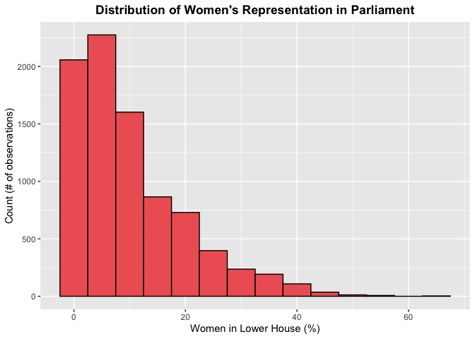

## Results

#### The boxplot shows women’s representation in parliament in countries with an effective gender quota, and without an effective gender quota.

###### Figure #2

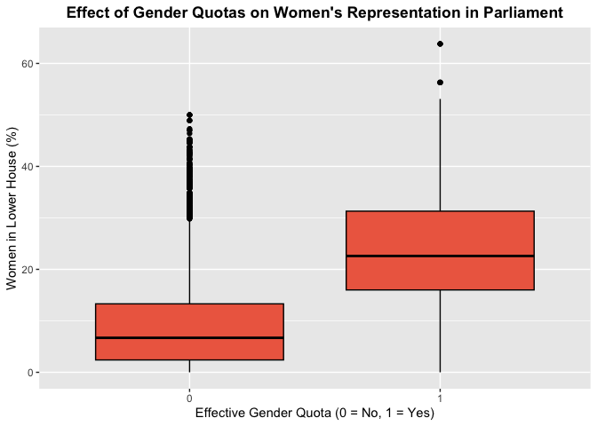

As seen above, countries that had effective gender quotas showed higher median levels of women’s representation in comparison to countries without quotas. The distribution for countries with effective quotas is shifted upward. This shows that these quotas are associated with increased representation in parliament. Overall, the boxplot supports my initial hypothesis that gender quotas are associated with higher levels of women’s representation in parliament.

### Regression

Regression Results: Women’s Representation and Gender Quotas

|  | Results |
| --- | --- |
| (Intercept) | 9.29*** |
|  | (0.10) |
|  | (<0.01) |
| effective.quota | 14.37*** |
|  | (0.41) |
|  | (<0.01) |
| Num.Obs. | 8518 |
| R2 | 0.126 |
| R2 Adj. | 0.126 |
| AIC | 62019.1 |
| BIC | 62040.3 |
| Log.Lik. | −31006.554 |
| RMSE | 9.22 |

+ p < 0.1, * p < 0.05, ** p < 0.01, *** p < 0.001

The regression analysis supports my hypothesis further showing not only a positive coefficient but, in the double digits. When there is no gender quota the expected percentage of women in parliament is 9.29%. In countries with an effective gender quota we expect on average a 14.37 percentage point increase in women’s representation compared to countries without quotas. These findings are statistically significant with the p-value being <0.001. However, these findings should not be interpreted as definitively causal because this analysis is cross-sectional, and gender quotas were not randomly assigned to countries. There may be other factors that influence both quota adoption and women’s representation that were not analyzed in this study.

## Conclusion

| Quota level | Mean representation | Median representation | SD | N |
| --- | --- | --- | --- | --- |
| 0 | 9.29 | 6.7 | 9.09 | 7977 |
| 1 | 23.66 | 22.6 | 10.93 | 541 |

Overall, the results provide strong support for my hypothesis that effective gender quotas are associated with higher levels of women’s representation in national legislatures. Both the boxplot and regression results show that countries with effective quotas tend to have significantly more women serving in parliament than countries without such quotas. The regression suggests that effective quotas are associated with an increase of about 14 percentage points in women’s representation, which is a larger difference than I expected. However, there are limitations to this analysis. To begin, the cross-sectional analysis means that this cannot establish causation. Future research could improve this analysis by adding control variables. More specifically, if I had more time or resources to spend on this project I would look more into the economic development in these regions and education levels. Higher education in countries may contribute to both the implementation of gender quotas, as well as how likely they are to have women in positions of power. Confounding variables like this need to be addressed to know whether this relationship is causal.